# MomentUm Orthogonalized by Newton-Schulz

Train Faster With Less GPUs and Great Performance

KHUN Kimang

kimang.khun@polytechnique.org

ក្រង AI

2026-03-10

# ខ្លឹមសារសង្ខេប

## ម៉ូអន (Muon)

ម៉ូអន (Muon) ជាបរមាករ<sup>1</sup> (optimizer) ដែលធ្វើប្រមាណវិធីខាងក្រោម

1. គណនាហ្គ្រាដ្យ៉ង់ (Gradient) របស់ប៉ារ៉ាម៉ែត្រ ${\mathbf{W}}$
2. ធ្វើបច្ចុប្បន្នភាពម៉ាទ្រីសម៉ូម៉ង់ (Momentum) ${\mathbf{M}}$ ដោយប្រើប្រាស់ហ្គ្រាដ្យ៉ង់
3. គណនាម៉ាទ្រីសអរតូកូណាល់ (Orthogonal) ${\mathbf{O}}$ របស់ ${\mathbf{M}}$
4. ធ្វើបច្ចុប្បន្នភាព ប៉ារ៉ាម៉ែត្រ ${\mathbf{W}}$ ដោយប្រើប្រាស់ ${\mathbf{O}}$
[^1]: អនុវត្តបានតែប៉ារ៉ាម៉ែត្រមាន២វិមាត្រ ដូចជាស្រទាប់លីនេអ៊ែរជាដើម

## ម៉ូអន (Muon) មានសមត្ថភាពខ្ពស់ជាង អាដាំ (Adam)

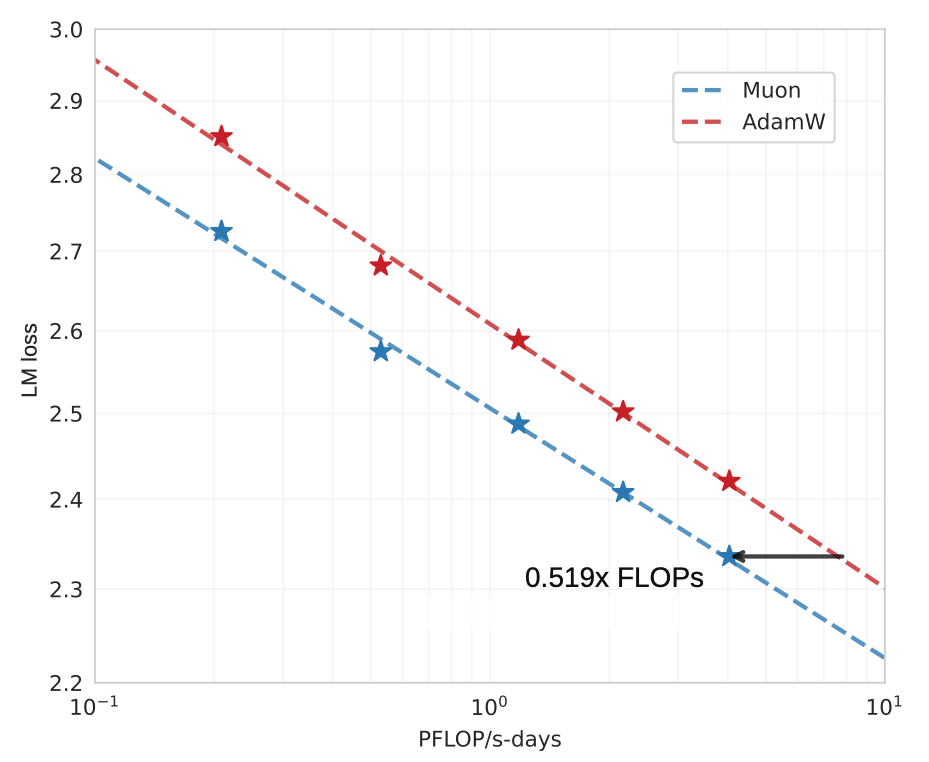

Figure 1: Scaling law experiments comparing Muon and Adam. Muon is $\approx$ 2$\times$ more computational efficient than Adam with compute optimal training.

Figure 1 of Liu et al. (2025).

## ម៉ូអនបង្កើនស្ថិរភាពនៃការបង្ហាត់ម៉ូដែលភាសា Kimi K2

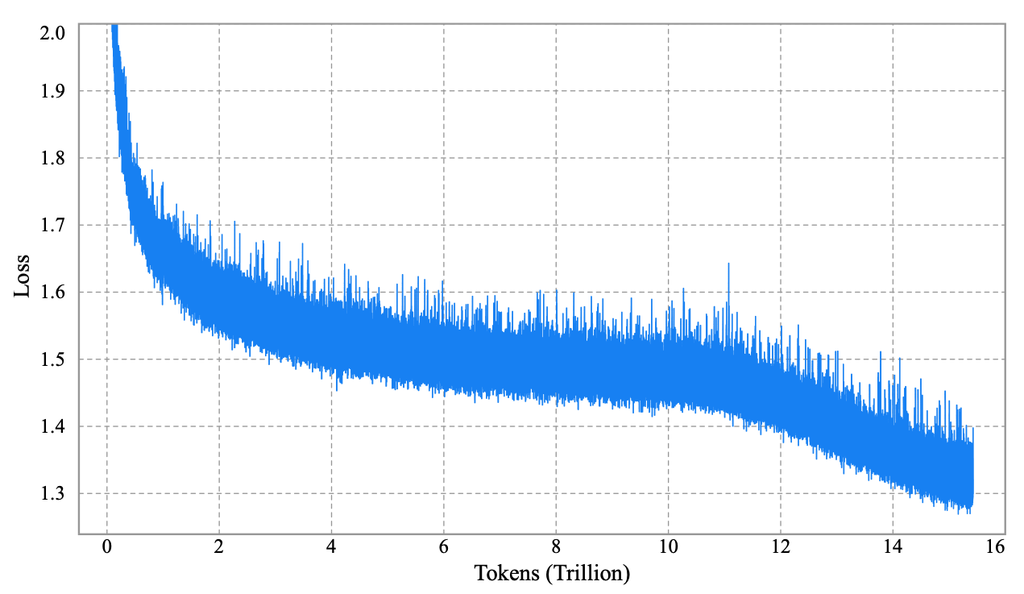

Figure 2: Per-step training loss curve of Kimi K2, **without smoothing or sub-sampling**. It shows no spikes throughout the entire training process. Note that we omit the very beginning of training for clarity.

Figure 3 of Team et al. (2025).

# Definition

## Linear Layer

- parameters: ${\mathbf{W}}\in{\mathbb{R}}^{k\times d}$
- forward pass: $\hat{{\boldsymbol{y}}}={\mathbf{W}}{\boldsymbol{x}}$, where ${\boldsymbol{x}}\in{\mathbb{R}}^{d}$

For example, in case $k=3$ and $d=4$, we have
$$\begin{bmatrix}
\hat{y}_{1} \\
\hat{y}_{2} \\
\hat{y}_{3}
\end{bmatrix}
=
\begin{bmatrix}
w_{11} & w_{12} & w_{13} & w_{14} \\
w_{21} & w_{22} & w_{23} & w_{24} \\
w_{31} & w_{32} & w_{33} & w_{34}
\end{bmatrix}
\begin{bmatrix}
x_{1} \\
x_{2} \\
x_{3} \\
x_{4}
\end{bmatrix}$$

- compute loss: $L({\boldsymbol{y}}, \hat{{\boldsymbol{y}}})$ where ${\boldsymbol{y}}\in{\mathbb{R}}^{k}$ is the ground-truth

## Gradient Descent

- backward pass: $\frac{\partial L}{\partial w_{ij}}$ for $1\le i\le k$ and $1\le j\le d$
- update:
  $$w_{ij}^{\mathrm{new}} \leftarrow w_{ij}^{\mathrm{old}} - \alpha \frac{\partial L}{\partial w_{ij}}$$

where $\alpha$ is the learning rate

## Gradient Descent

- backward pass: $\frac{\partial L}{\partial w_{ij}}$ for $1\le i\le k$ and $1\le j\le d$
- update:
  $$w_{ij} \leftarrow w_{ij} - \alpha \frac{\partial L}{\partial w_{ij}}$$

For $k=3$ and $d=4$, we have
$${\mathbf{W}}
\leftarrow
\begin{bmatrix}
w_{11} & w_{12} & w_{13} & w_{14} \\
w_{21} & w_{22} & w_{23} & w_{24} \\
w_{31} & w_{32} & w_{33} & w_{34}
\end{bmatrix}
- \alpha
\begin{bmatrix}
\frac{\partial L}{\partial w_{11}} & \frac{\partial L}{\partial w_{12}} & \frac{\partial L}{\partial w_{13}} & \frac{\partial L}{\partial w_{14}} \\
\frac{\partial L}{\partial w_{21}} & \frac{\partial L}{\partial w_{22}} & \frac{\partial L}{\partial w_{23}} & \frac{\partial L}{\partial w_{24}} \\
\frac{\partial L}{\partial w_{31}} & \frac{\partial L}{\partial w_{32}} & \frac{\partial L}{\partial w_{33}} & \frac{\partial L}{\partial w_{34}}
\end{bmatrix}$$

## Adaptive Moment Estimation (Adam)

- backward pass: $\frac{\partial L}{\partial w_{ij}}$ for $1\le i\le k$ and $1\le j\le d$
- update momentum ${\mathbf{M}}\in{\mathbb{R}}^{k\times d}$ where
  $$m_{ij} \leftarrow \beta_1 m_{ij} + (1-\beta_1) \frac{\partial L}{\partial w_{ij}}$$
- update Root Mean Squared propagation (RMSprop):
  $$\nu_{ij} \leftarrow \beta_2 \nu_{ij} + (1-\beta_2) \left(\frac{\partial L}{\partial w_{ij}}\right)^2$$
- update:
  $$w_{ij} \leftarrow w_{ij} - \alpha \frac{m_{ij}}{\sqrt{\nu_{ij}} + \varepsilon}$$

## Concept of Muon

- backward pass: $\frac{\partial L}{\partial w_{ij}}$ for $1\le i\le k$ and $1\le j\le d$
- update momentum ${\mathbf{M}}\in{\mathbb{R}}^{k\times d}$ where
  $$m_{ij} \leftarrow \beta_1 m_{ij} + (1-\beta_1) \frac{\partial L}{\partial w_{ij}}$$
- compute orthogonal of ${\mathbf{M}}$:
  $$\mathrm{Ortho}({\mathbf{M}}) := \arg\min_{{\mathbf{O}}}{||{\mathbf{O}}-{\mathbf{M}}||} \mathrm{\ subject\ to:\ either\ } {\mathbf{O}}{\mathbf{O}}^{\top} = {\mathbf{I}}_{k\times k} \mathrm{\ or\ } {\mathbf{O}}^{\top}{\mathbf{O}}= {\mathbf{I}}_{d\times d} \tag{1}$$
- update ${\mathbf{W}}\leftarrow {\mathbf{W}}-\alpha \mathrm{Ortho}({\mathbf{M}})$

## Concept of Muon

- Equation 1 has one known solution: ${\mathbf{O}}={\mathbf{U}}{\mathbf{I}}_{k\times d}{\mathbf{V}}^{\top}$ where ${\mathbf{M}}={\mathbf{U}}{\mathbf{S}}{\mathbf{V}}^{\top}$,
  - ${\mathbf{S}}$ is diagonal
  - ${\mathbf{U}}$ and ${\mathbf{V}}$ are orthonormal
  - ${\mathbf{U}}{\mathbf{U}}^{\top} ={\mathbf{U}}^{\top}{\mathbf{U}}={\mathbf{I}}_{k\times k}$ and ${\mathbf{V}}{\mathbf{V}}^{\top} ={\mathbf{V}}^{\top}{\mathbf{V}}={\mathbf{I}}_{d\times d}$
- ${\mathbf{S}}$, ${\mathbf{U}}$, and ${\mathbf{V}}$ can be computed by **Single Value Decomposition (SVD)**
- SVD is **computationally expensive**

## Design of Muon

- let $\phi(x):=ax + bx^3 + cx^5$ be a quintic polynomial
- apply $\phi$ on ${\mathbf{M}}$ gives

$$\begin{aligned}
a{\mathbf{M}}+ b({\mathbf{M}}{\mathbf{M}}^{\top}){\mathbf{M}}+ c({\mathbf{M}}{\mathbf{M}}^{\top})^2{\mathbf{M}}
&= a{\mathbf{U}}{\mathbf{S}}{\mathbf{V}}^{\top} +b \left({\mathbf{U}}{\mathbf{S}}{\mathbf{V}}^{\top}({\mathbf{U}}{\mathbf{S}}{\mathbf{V}}^{\top})^{\top}\right){\mathbf{U}}{\mathbf{S}}{\mathbf{V}}^{\top} +c\left({\mathbf{U}}{\mathbf{S}}{\mathbf{V}}^{\top}({\mathbf{U}}{\mathbf{S}}{\mathbf{V}}^{\top})^{\top}\right)^2{\mathbf{U}}{\mathbf{S}}{\mathbf{V}}^{\top} \\
&= a{\mathbf{U}}{\mathbf{S}}{\mathbf{V}}^{\top} +b \left({\mathbf{U}}{\mathbf{S}}{\mathbf{V}}^{\top}{\mathbf{V}}({\mathbf{U}}{\mathbf{S}})^{\top}\right){\mathbf{U}}{\mathbf{S}}{\mathbf{V}}^{\top} +c\left({\mathbf{U}}{\mathbf{S}}{\mathbf{V}}^{\top}({\mathbf{U}}{\mathbf{S}}{\mathbf{V}}^{\top})^{\top}\right)^2{\mathbf{U}}{\mathbf{S}}{\mathbf{V}}^{\top} \\
&= a{\mathbf{U}}{\mathbf{S}}{\mathbf{V}}^{\top} +b \left({\mathbf{U}}{\mathbf{S}}({\mathbf{U}}{\mathbf{S}})^{\top}\right){\mathbf{U}}{\mathbf{S}}{\mathbf{V}}^{\top} +c\left({\mathbf{U}}{\mathbf{S}}{\mathbf{V}}^{\top}({\mathbf{U}}{\mathbf{S}}{\mathbf{V}}^{\top})^{\top}\right)^2{\mathbf{U}}{\mathbf{S}}{\mathbf{V}}^{\top} \\
&= a{\mathbf{U}}{\mathbf{S}}{\mathbf{V}}^{\top} +b \left({\mathbf{U}}{\mathbf{S}}{\mathbf{S}}^{\top}{\mathbf{U}}^{\top}\right){\mathbf{U}}{\mathbf{S}}{\mathbf{V}}^{\top} +c\left({\mathbf{U}}{\mathbf{S}}{\mathbf{S}}^{\top}{\mathbf{U}}^{\top}\right)\left({\mathbf{U}}{\mathbf{S}}{\mathbf{S}}^{\top}{\mathbf{U}}^{\top}\right){\mathbf{U}}{\mathbf{S}}{\mathbf{V}}^{\top} \\
&= a{\mathbf{U}}{\mathbf{S}}{\mathbf{V}}^{\top} +b {\mathbf{U}}{\mathbf{S}}^{3}{\mathbf{V}}^{\top} +c\left({\mathbf{U}}{\mathbf{S}}^{2}{\mathbf{U}}^{\top}\right){\mathbf{U}}{\mathbf{S}}^{3}{\mathbf{V}}^{\top} \\
&= a{\mathbf{U}}{\mathbf{S}}{\mathbf{V}}^{\top} +b {\mathbf{U}}{\mathbf{S}}^{3}{\mathbf{V}}^{\top} +c{\mathbf{U}}{\mathbf{S}}^{5}{\mathbf{V}}^{\top} \\
&= {\mathbf{U}}\left(a{\mathbf{S}}+b {\mathbf{S}}^{3} +c{\mathbf{S}}^{5}\right){\mathbf{V}}^{\top} \\
&= {\mathbf{U}}\phi({\mathbf{S}}){\mathbf{V}}^{\top}
\end{aligned}$$

## Design of Muon

- let $\phi(x):=ax + bx^3 + cx^5$ be a quintic polynomial
- we have
  $$\begin{aligned}
  \phi({\mathbf{M}})
  &= {\mathbf{U}}\phi({\mathbf{S}}){\mathbf{V}}^{\top} \\
  \phi\big(\phi({\mathbf{M}})\big)
  &= {\mathbf{U}}\phi\big(\phi({\mathbf{S}})\big){\mathbf{V}}^{\top} \\
  \phi\Big(\phi\big(\phi({\mathbf{M}})\big)\Big)
  &= {\mathbf{U}}\phi\Big(\phi\big(\phi({\mathbf{S}})\big)\Big){\mathbf{V}}^{\top} \\
  &\vdots \\
  \phi^N({\mathbf{M}})
  &= {\mathbf{U}}\phi^N({\mathbf{S}}){\mathbf{V}}^{\top}
  \end{aligned}$$

## Design of Muon

- Since ${\mathbf{S}}$ is diagonal, $\phi({\mathbf{S}})$ simply applies $\phi$ to each diagonal element<sup>1</sup> of ${\mathbf{S}}$
- For example, in case $k=3, d=4$,
  $$\phi({\mathbf{S}})
  =
  \begin{bmatrix}
  \phi(s_{11}) & 0 & 0 & 0 \\
  0 & \phi(s_{22}) & 0 & 0 \\
  0 & 0 & \phi(s_{33}) & 0
  \end{bmatrix}, \mathrm{\ and\ }
  \phi^N({\mathbf{S}})
  =
  \begin{bmatrix}
  \phi^N(s_{11}) & 0 & 0 & 0 \\
  0 & \phi^N(s_{22}) & 0 & 0 \\
  0 & 0 & \phi^N(s_{33}) & 0
  \end{bmatrix}$$
- we can select the coefficients $(a, b, c)$ such that $\phi^N(x) \to 1$ as $N\to\infty$ for all $x\in(0, 1]$
- in that case, $\phi^N({\mathbf{S}})\to{\mathbf{I}}_{k\times d }$ as $N\to\infty$ and $\phi^N({\mathbf{M}})\to {\mathbf{O}}$
[^2]: Note that all exponents in $\phi$ are odd number

## Muon

- backward pass: $\frac{\partial L}{\partial w_{ij}}$ for $1\le i\le k$ and $1\le j\le d$
- update momentum ${\mathbf{M}}\in{\mathbb{R}}^{k\times d}$ where
  $$m_{ij} \leftarrow \beta_1 m_{ij} + (1-\beta_1) \frac{\partial L}{\partial w_{ij}}$$
- normalize the momentum
  $${\mathbf{M}}':=\frac{{\mathbf{M}}}{||{\mathbf{M}}||+\varepsilon}$$
- with<sup>1</sup> $a, b, c = (3.4445, -4.7750, 2.0315)$, compute of ${\mathbf{O}}:=\phi^5({\mathbf{M}}')$
- update ${\mathbf{W}}\leftarrow {\mathbf{W}}-\alpha {\mathbf{O}}$
[^3]: Sourced from [github](https://github.com/KellerJordan/Muon/blob/6399c658d3c4a3356ba823fa6664b10e23871068/muon.py#L16)

## Muon consumes GPU memory less than Adam

- Muon needs storage for *momentum*, each equals to parameter storage
- Adam needs storage for *momentum*, and **RMSprop**, each equals to parameter storage

## References

Liu, Jingyuan, Jianlin Su, Xingcheng Yao, Zhejun Jiang, Guokun Lai, Yulun Du, Yidao Qin, et al. 2025. “Muon Is Scalable for LLM Training.” https://arxiv.org/abs/2502.16982.

Team, Kimi, Yifan Bai, Yiping Bao, Guanduo Chen, Jiahao Chen, Ningxin Chen, Ruijue Chen, et al. 2025. “Kimi K2: Open Agentic Intelligence.” *arXiv Preprint arXiv:2507.20534*.